# Risk Factor Analysis

## Outcome Variable

**Outcome Variable:** ever_co

## Predictor Variables

**Intervention Variable:** exclfeed36

**Adjustment Set:**

- arm
- sex
- W_mage
- meducyrs
- feducyrs
- hhwealth_quart
- hfoodsec
- W_mhtcm
- vagbrth
- W_gagebrth
- W_birthwt
- W_birthlen
- W_nrooms
- W_nchldlt5
- month
- brthmon
- W_parity
- impfloor
- impsan
- safeh20
- delta_W_mage
- delta_meducyrs
- delta_feducyrs
- delta_hhwealth_quart
- delta_hfoodsec
- delta_W_mhtcm
- delta_vagbrth
- delta_W_gagebrth
- delta_W_birthwt
- delta_W_birthlen
- delta_W_nrooms
- delta_W_nchldlt5
- delta_month
- delta_brthmon
- delta_W_parity
- delta_impfloor
- delta_impsan
- delta_safeh20

## Stratifying Variables

The analysis was stratified on these variable(s):

- agecat
- studyid
- country

## Data Summary

| agecat | studyid | country | exclfeed36 | ever_co | n_cell | n |
| --- | --- | --- | --- | --- | --- | --- |
| 0-24 months | ki0047075b-MAL-ED | BANGLADESH | 1 | 0 | 51 | 251 |
| 0-24 months | ki0047075b-MAL-ED | BANGLADESH | 1 | 1 | 13 | 251 |
| 0-24 months | ki0047075b-MAL-ED | BANGLADESH | 0 | 0 | 161 | 251 |
| 0-24 months | ki0047075b-MAL-ED | BANGLADESH | 0 | 1 | 26 | 251 |
| 0-24 months | ki0047075b-MAL-ED | BRAZIL | 1 | 0 | 18 | 225 |
| 0-24 months | ki0047075b-MAL-ED | BRAZIL | 1 | 1 | 0 | 225 |
| 0-24 months | ki0047075b-MAL-ED | BRAZIL | 0 | 0 | 205 | 225 |
| 0-24 months | ki0047075b-MAL-ED | BRAZIL | 0 | 1 | 2 | 225 |
| 0-24 months | ki0047075b-MAL-ED | INDIA | 1 | 0 | 7 | 243 |
| 0-24 months | ki0047075b-MAL-ED | INDIA | 1 | 1 | 0 | 243 |
| 0-24 months | ki0047075b-MAL-ED | INDIA | 0 | 0 | 182 | 243 |
| 0-24 months | ki0047075b-MAL-ED | INDIA | 0 | 1 | 54 | 243 |
| 0-24 months | ki0047075b-MAL-ED | NEPAL | 1 | 0 | 14 | 238 |
| 0-24 months | ki0047075b-MAL-ED | NEPAL | 1 | 1 | 1 | 238 |
| 0-24 months | ki0047075b-MAL-ED | NEPAL | 0 | 0 | 203 | 238 |
| 0-24 months | ki0047075b-MAL-ED | NEPAL | 0 | 1 | 20 | 238 |
| 0-24 months | ki0047075b-MAL-ED | PERU | 1 | 0 | 16 | 287 |
| 0-24 months | ki0047075b-MAL-ED | PERU | 1 | 1 | 0 | 287 |
| 0-24 months | ki0047075b-MAL-ED | PERU | 0 | 0 | 260 | 287 |
| 0-24 months | ki0047075b-MAL-ED | PERU | 0 | 1 | 11 | 287 |
| 0-24 months | ki0047075b-MAL-ED | SOUTH AFRICA | 1 | 0 | 0 | 281 |
| 0-24 months | ki0047075b-MAL-ED | SOUTH AFRICA | 1 | 1 | 0 | 281 |
| 0-24 months | ki0047075b-MAL-ED | SOUTH AFRICA | 0 | 0 | 260 | 281 |
| 0-24 months | ki0047075b-MAL-ED | SOUTH AFRICA | 0 | 1 | 21 | 281 |
| 0-24 months | ki0047075b-MAL-ED | TANZANIA, UNITED REPUBLIC OF | 1 | 0 | 1 | 256 |
| 0-24 months | ki0047075b-MAL-ED | TANZANIA, UNITED REPUBLIC OF | 1 | 1 | 0 | 256 |
| 0-24 months | ki0047075b-MAL-ED | TANZANIA, UNITED REPUBLIC OF | 0 | 0 | 232 | 256 |
| 0-24 months | ki0047075b-MAL-ED | TANZANIA, UNITED REPUBLIC OF | 0 | 1 | 23 | 256 |
| 0-24 months | ki1000108-CMC-V-BCS-2002 | INDIA | 1 | 0 | 8 | 9 |
| 0-24 months | ki1000108-CMC-V-BCS-2002 | INDIA | 1 | 1 | 1 | 9 |

[output cut: 174 more lines]

The following strata were considered:

- agecat: 0-24 months, studyid: ki0047075b-MAL-ED, country: BANGLADESH
- agecat: 0-24 months, studyid: ki0047075b-MAL-ED, country: BRAZIL
- agecat: 0-24 months, studyid: ki0047075b-MAL-ED, country: INDIA
- agecat: 0-24 months, studyid: ki0047075b-MAL-ED, country: NEPAL
- agecat: 0-24 months, studyid: ki0047075b-MAL-ED, country: PERU
- agecat: 0-24 months, studyid: ki0047075b-MAL-ED, country: SOUTH AFRICA
- agecat: 0-24 months, studyid: ki0047075b-MAL-ED, country: TANZANIA, UNITED REPUBLIC OF
- agecat: 0-24 months, studyid: ki1000108-CMC-V-BCS-2002, country: INDIA
- agecat: 0-24 months, studyid: ki1000108-IRC, country: INDIA
- agecat: 0-24 months, studyid: ki1000109-EE, country: PAKISTAN
- agecat: 0-24 months, studyid: ki1000304b-SAS-FoodSuppl, country: INDIA
- agecat: 0-24 months, studyid: ki1017093b-PROVIDE, country: BANGLADESH
- agecat: 0-24 months, studyid: ki1101329-Keneba, country: GAMBIA
- agecat: 0-24 months, studyid: ki1113344-GMS-Nepal, country: NEPAL
- agecat: 0-24 months, studyid: ki1148112-LCNI-5, country: MALAWI
- agecat: 0-24 months, studyid: kiGH5241-JiVitA-3, country: BANGLADESH
- agecat: 0-24 months, studyid: kiGH5241-JiVitA-4, country: BANGLADESH
- agecat: 0-6 months, studyid: ki0047075b-MAL-ED, country: BANGLADESH
- agecat: 0-6 months, studyid: ki0047075b-MAL-ED, country: BRAZIL
- agecat: 0-6 months, studyid: ki0047075b-MAL-ED, country: INDIA
- agecat: 0-6 months, studyid: ki0047075b-MAL-ED, country: NEPAL
- agecat: 0-6 months, studyid: ki0047075b-MAL-ED, country: PERU
- agecat: 0-6 months, studyid: ki0047075b-MAL-ED, country: SOUTH AFRICA
- agecat: 0-6 months, studyid: ki0047075b-MAL-ED, country: TANZANIA, UNITED REPUBLIC OF
- agecat: 0-6 months, studyid: ki1000108-CMC-V-BCS-2002, country: INDIA
- agecat: 0-6 months, studyid: ki1000108-IRC, country: INDIA
- agecat: 0-6 months, studyid: ki1000109-EE, country: PAKISTAN
- agecat: 0-6 months, studyid: ki1000304b-SAS-FoodSuppl, country: INDIA
- agecat: 0-6 months, studyid: ki1017093b-PROVIDE, country: BANGLADESH
- agecat: 0-6 months, studyid: ki1101329-Keneba, country: GAMBIA
- agecat: 0-6 months, studyid: ki1113344-GMS-Nepal, country: NEPAL
- agecat: 0-6 months, studyid: ki1148112-LCNI-5, country: MALAWI
- agecat: 0-6 months, studyid: kiGH5241-JiVitA-3, country: BANGLADESH
- agecat: 0-6 months, studyid: kiGH5241-JiVitA-4, country: BANGLADESH
- agecat: 6-24 months, studyid: ki0047075b-MAL-ED, country: BANGLADESH
- agecat: 6-24 months, studyid: ki0047075b-MAL-ED, country: BRAZIL
- agecat: 6-24 months, studyid: ki0047075b-MAL-ED, country: INDIA
- agecat: 6-24 months, studyid: ki0047075b-MAL-ED, country: NEPAL
- agecat: 6-24 months, studyid: ki0047075b-MAL-ED, country: PERU
- agecat: 6-24 months, studyid: ki0047075b-MAL-ED, country: SOUTH AFRICA
- agecat: 6-24 months, studyid: ki0047075b-MAL-ED, country: TANZANIA, UNITED REPUBLIC OF
- agecat: 6-24 months, studyid: ki1000108-CMC-V-BCS-2002, country: INDIA
- agecat: 6-24 months, studyid: ki1000108-IRC, country: INDIA
- agecat: 6-24 months, studyid: ki1000109-EE, country: PAKISTAN
- agecat: 6-24 months, studyid: ki1000304b-SAS-FoodSuppl, country: INDIA
- agecat: 6-24 months, studyid: ki1017093b-PROVIDE, country: BANGLADESH
- agecat: 6-24 months, studyid: ki1101329-Keneba, country: GAMBIA
- agecat: 6-24 months, studyid: ki1113344-GMS-Nepal, country: NEPAL
- agecat: 6-24 months, studyid: ki1148112-LCNI-5, country: MALAWI
- agecat: 6-24 months, studyid: kiGH5241-JiVitA-3, country: BANGLADESH
- agecat: 6-24 months, studyid: kiGH5241-JiVitA-4, country: BANGLADESH

### Dropped Strata

Some strata were dropped due to rare outcomes:

- agecat: 0-24 months, studyid: ki0047075b-MAL-ED, country: BRAZIL
- agecat: 0-24 months, studyid: ki0047075b-MAL-ED, country: INDIA
- agecat: 0-24 months, studyid: ki0047075b-MAL-ED, country: NEPAL
- agecat: 0-24 months, studyid: ki0047075b-MAL-ED, country: PERU
- agecat: 0-24 months, studyid: ki0047075b-MAL-ED, country: SOUTH AFRICA
- agecat: 0-24 months, studyid: ki0047075b-MAL-ED, country: TANZANIA, UNITED REPUBLIC OF
- agecat: 0-24 months, studyid: ki1000108-CMC-V-BCS-2002, country: INDIA
- agecat: 0-24 months, studyid: ki1000108-IRC, country: INDIA
- agecat: 0-24 months, studyid: ki1000304b-SAS-FoodSuppl, country: INDIA
- agecat: 0-24 months, studyid: ki1148112-LCNI-5, country: MALAWI
- agecat: 0-6 months, studyid: ki0047075b-MAL-ED, country: BANGLADESH
- agecat: 0-6 months, studyid: ki0047075b-MAL-ED, country: BRAZIL
- agecat: 0-6 months, studyid: ki0047075b-MAL-ED, country: INDIA
- agecat: 0-6 months, studyid: ki0047075b-MAL-ED, country: NEPAL
- agecat: 0-6 months, studyid: ki0047075b-MAL-ED, country: PERU
- agecat: 0-6 months, studyid: ki0047075b-MAL-ED, country: SOUTH AFRICA
- agecat: 0-6 months, studyid: ki0047075b-MAL-ED, country: TANZANIA, UNITED REPUBLIC OF
- agecat: 0-6 months, studyid: ki1000108-CMC-V-BCS-2002, country: INDIA
- agecat: 0-6 months, studyid: ki1000108-IRC, country: INDIA
- agecat: 0-6 months, studyid: ki1000304b-SAS-FoodSuppl, country: INDIA
- agecat: 0-6 months, studyid: ki1017093b-PROVIDE, country: BANGLADESH
- agecat: 0-6 months, studyid: ki1148112-LCNI-5, country: MALAWI
- agecat: 6-24 months, studyid: ki0047075b-MAL-ED, country: BRAZIL
- agecat: 6-24 months, studyid: ki0047075b-MAL-ED, country: INDIA
- agecat: 6-24 months, studyid: ki0047075b-MAL-ED, country: NEPAL
- agecat: 6-24 months, studyid: ki0047075b-MAL-ED, country: PERU
- agecat: 6-24 months, studyid: ki0047075b-MAL-ED, country: SOUTH AFRICA
- agecat: 6-24 months, studyid: ki0047075b-MAL-ED, country: TANZANIA, UNITED REPUBLIC OF
- agecat: 6-24 months, studyid: ki1000108-CMC-V-BCS-2002, country: INDIA
- agecat: 6-24 months, studyid: ki1000108-IRC, country: INDIA
- agecat: 6-24 months, studyid: ki1000304b-SAS-FoodSuppl, country: INDIA
- agecat: 6-24 months, studyid: ki1148112-LCNI-5, country: MALAWI

## Methods Detail

We’re interested in the causal parameters $E[Y_a]$ for all values of $a \in \mathcal{A}$. These parameters represent the mean outcome if, possibly contrary to fact, we intervened to set all units to have $A=a$. Under the randomization and positivity assumptions, these are identified by the statistical parameters $\psi_a=E_W[E_{Y|A,W}(Y|A=a,W)]$. In addition, we’re interested in the mean of $Y$, $E[Y]$ under no intervention (the observed mean). We will estimate these parameters by using SuperLearner to fit the relevant likelihood factors – $E_{Y|A,W}(Y|A=a,W)$ and $p(A=a|W)$, and then updating our likelihood fit using a joint TMLE.

For unadjusted analyses ($W=\{\}$), initial likelihoods were estimated using Lrnr_glm to estimate the simple $E(Y|A)$ and Lrnr_mean to estimate $p(A)$. For adjusted analyses, a small library containing Lrnr_glmnet, Lrnr_xgboost, and Lrnr_mean was used.

Having estimated these parameters, we will then use the delta method to estimate relative risks and attributable risks relative to a prespecified baseline level of $A$.

# Results Detail

## Results Plots

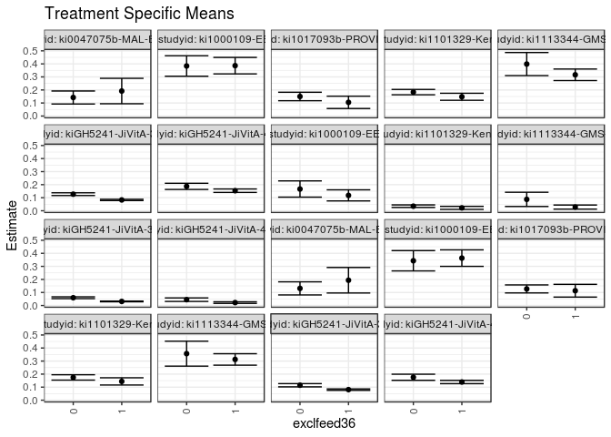

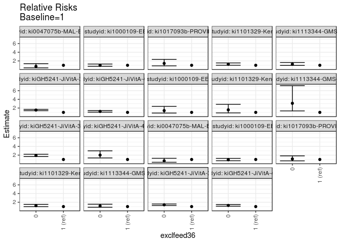

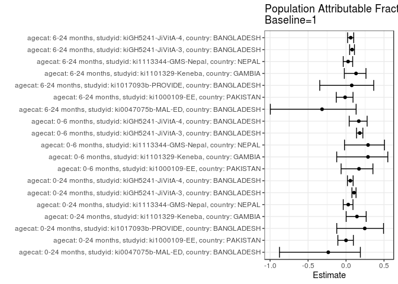

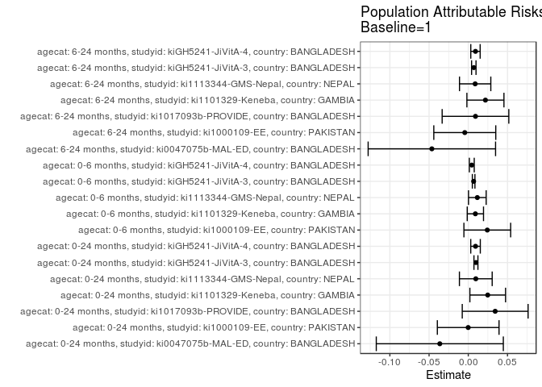

## Results Table

### Parameter: TSM

| agecat | studyid | country | intervention_level | baseline_level | estimate | ci_lower | ci_upper |
| --- | --- | --- | --- | --- | --- | --- | --- |
| 0-24 months | ki0047075b-MAL-ED | BANGLADESH | 1 | NA | 0.1916961 | 0.0943188 | 0.2890735 |
| 0-24 months | ki0047075b-MAL-ED | BANGLADESH | 0 | NA | 0.1422858 | 0.0924620 | 0.1921095 |
| 0-24 months | ki1000109-EE | PAKISTAN | 1 | NA | 0.3861798 | 0.3229264 | 0.4494331 |
| 0-24 months | ki1000109-EE | PAKISTAN | 0 | NA | 0.3836732 | 0.3052424 | 0.4621040 |
| 0-24 months | ki1017093b-PROVIDE | BANGLADESH | 1 | NA | 0.1049821 | 0.0577296 | 0.1522345 |
| 0-24 months | ki1017093b-PROVIDE | BANGLADESH | 0 | NA | 0.1499360 | 0.1175907 | 0.1822814 |
| 0-24 months | ki1101329-Keneba | GAMBIA | 1 | NA | 0.1476860 | 0.1208081 | 0.1745639 |
| 0-24 months | ki1101329-Keneba | GAMBIA | 0 | NA | 0.1834506 | 0.1630706 | 0.2038305 |
| 0-24 months | ki1113344-GMS-Nepal | NEPAL | 1 | NA | 0.3161683 | 0.2720582 | 0.3602785 |
| 0-24 months | ki1113344-GMS-Nepal | NEPAL | 0 | NA | 0.3984516 | 0.3101534 | 0.4867498 |
| 0-24 months | kiGH5241-JiVitA-3 | BANGLADESH | 1 | NA | 0.0830429 | 0.0782988 | 0.0877871 |
| 0-24 months | kiGH5241-JiVitA-3 | BANGLADESH | 0 | NA | 0.1272130 | 0.1168074 | 0.1376186 |
| 0-24 months | kiGH5241-JiVitA-4 | BANGLADESH | 1 | NA | 0.1537706 | 0.1404214 | 0.1671198 |
| 0-24 months | kiGH5241-JiVitA-4 | BANGLADESH | 0 | NA | 0.1871362 | 0.1633539 | 0.2109184 |
| 0-6 months | ki1000109-EE | PAKISTAN | 1 | NA | 0.1178572 | 0.0753132 | 0.1604013 |
| 0-6 months | ki1000109-EE | PAKISTAN | 0 | NA | 0.1667469 | 0.1045518 | 0.2289421 |
| 0-6 months | ki1101329-Keneba | GAMBIA | 1 | NA | 0.0222262 | 0.0106813 | 0.0337711 |
| 0-6 months | ki1101329-Keneba | GAMBIA | 0 | NA | 0.0351404 | 0.0253445 | 0.0449362 |
| 0-6 months | ki1113344-GMS-Nepal | NEPAL | 1 | NA | 0.0282353 | 0.0124722 | 0.0439984 |
| 0-6 months | ki1113344-GMS-Nepal | NEPAL | 0 | NA | 0.0873786 | 0.0327917 | 0.1419656 |
| 0-6 months | kiGH5241-JiVitA-3 | BANGLADESH | 1 | NA | 0.0309152 | 0.0281329 | 0.0336975 |
| 0-6 months | kiGH5241-JiVitA-3 | BANGLADESH | 0 | NA | 0.0594308 | 0.0523665 | 0.0664950 |
| 0-6 months | kiGH5241-JiVitA-4 | BANGLADESH | 1 | NA | 0.0221490 | 0.0161792 | 0.0281189 |
| 0-6 months | kiGH5241-JiVitA-4 | BANGLADESH | 0 | NA | 0.0445531 | 0.0309842 | 0.0581221 |
| 6-24 months | ki0047075b-MAL-ED | BANGLADESH | 1 | NA | 0.1935031 | 0.0957117 | 0.2912946 |
| 6-24 months | ki0047075b-MAL-ED | BANGLADESH | 0 | NA | 0.1309656 | 0.0807381 | 0.1811930 |
| 6-24 months | ki1000109-EE | PAKISTAN | 1 | NA | 0.3631571 | 0.2998754 | 0.4264388 |
| 6-24 months | ki1000109-EE | PAKISTAN | 0 | NA | 0.3429073 | 0.2651588 | 0.4206557 |
| 6-24 months | ki1017093b-PROVIDE | BANGLADESH | 1 | NA | 0.1131653 | 0.0643160 | 0.1620145 |
| 6-24 months | ki1017093b-PROVIDE | BANGLADESH | 0 | NA | 0.1268733 | 0.0963030 | 0.1574437 |
| 6-24 months | ki1101329-Keneba | GAMBIA | 1 | NA | 0.1441167 | 0.1163408 | 0.1718927 |
| 6-24 months | ki1101329-Keneba | GAMBIA | 0 | NA | 0.1745848 | 0.1542594 | 0.1949102 |
| 6-24 months | ki1113344-GMS-Nepal | NEPAL | 1 | NA | 0.3125297 | 0.2684828 | 0.3565766 |
| 6-24 months | ki1113344-GMS-Nepal | NEPAL | 0 | NA | 0.3567330 | 0.2612622 | 0.4522037 |
| 6-24 months | kiGH5241-JiVitA-3 | BANGLADESH | 1 | NA | 0.0811067 | 0.0756364 | 0.0865770 |
| 6-24 months | kiGH5241-JiVitA-3 | BANGLADESH | 0 | NA | 0.1147740 | 0.1022787 | 0.1272693 |
| 6-24 months | kiGH5241-JiVitA-4 | BANGLADESH | 1 | NA | 0.1395015 | 0.1269638 | 0.1520393 |
| 6-24 months | kiGH5241-JiVitA-4 | BANGLADESH | 0 | NA | 0.1758256 | 0.1524274 | 0.1992239 |

### Parameter: E(Y)

| agecat | studyid | country | intervention_level | baseline_level | estimate | ci_lower | ci_upper |
| --- | --- | --- | --- | --- | --- | --- | --- |
| 0-24 months | ki0047075b-MAL-ED | BANGLADESH | NA | NA | 0.1553785 | 0.1104725 | 0.2002845 |
| 0-24 months | ki1000109-EE | PAKISTAN | NA | NA | 0.3860590 | 0.3365861 | 0.4355318 |
| 0-24 months | ki1017093b-PROVIDE | BANGLADESH | NA | NA | 0.1392801 | 0.1124135 | 0.1661468 |
| 0-24 months | ki1101329-Keneba | GAMBIA | NA | NA | 0.1724660 | 0.1558341 | 0.1890978 |
| 0-24 months | ki1113344-GMS-Nepal | NEPAL | NA | NA | 0.3257576 | 0.2857449 | 0.3657703 |
| 0-24 months | kiGH5241-JiVitA-3 | BANGLADESH | NA | NA | 0.0928037 | 0.0883057 | 0.0973017 |
| 0-24 months | kiGH5241-JiVitA-4 | BANGLADESH | NA | NA | 0.1630101 | 0.1508647 | 0.1751555 |
| 0-6 months | ki1000109-EE | PAKISTAN | NA | NA | 0.1420912 | 0.1066114 | 0.1775709 |
| 0-6 months | ki1101329-Keneba | GAMBIA | NA | NA | 0.0312658 | 0.0236039 | 0.0389276 |
| 0-6 months | ki1113344-GMS-Nepal | NEPAL | NA | NA | 0.0397727 | 0.0230879 | 0.0564576 |
| 0-6 months | kiGH5241-JiVitA-3 | BANGLADESH | NA | NA | 0.0377388 | 0.0349183 | 0.0405593 |
| 0-6 months | kiGH5241-JiVitA-4 | BANGLADESH | NA | NA | 0.0266227 | 0.0211044 | 0.0321409 |
| 6-24 months | ki0047075b-MAL-ED | BANGLADESH | NA | NA | 0.1470588 | 0.1019690 | 0.1921487 |
| 6-24 months | ki1000109-EE | PAKISTAN | NA | NA | 0.3586957 | 0.3096263 | 0.4077650 |
| 6-24 months | ki1017093b-PROVIDE | BANGLADESH | NA | NA | 0.1223491 | 0.0963874 | 0.1483108 |
| 6-24 months | ki1101329-Keneba | GAMBIA | NA | NA | 0.1659664 | 0.1492505 | 0.1826823 |
| 6-24 months | ki1113344-GMS-Nepal | NEPAL | NA | NA | 0.3212928 | 0.2813480 | 0.3612376 |
| 6-24 months | kiGH5241-JiVitA-3 | BANGLADESH | NA | NA | 0.0881474 | 0.0829797 | 0.0933152 |
| 6-24 months | kiGH5241-JiVitA-4 | BANGLADESH | NA | NA | 0.1486695 | 0.1373410 | 0.1599979 |

### Parameter: RR

| agecat | studyid | country | intervention_level | baseline_level | estimate | ci_lower | ci_upper |
| --- | --- | --- | --- | --- | --- | --- | --- |
| 0-24 months | ki0047075b-MAL-ED | BANGLADESH | 1 | 1 | 1.0000000 | 1.0000000 | 1.000000 |
| 0-24 months | ki0047075b-MAL-ED | BANGLADESH | 0 | 1 | 0.7422463 | 0.4031108 | 1.366695 |
| 0-24 months | ki1000109-EE | PAKISTAN | 1 | 1 | 1.0000000 | 1.0000000 | 1.000000 |
| 0-24 months | ki1000109-EE | PAKISTAN | 0 | 1 | 0.9935094 | 0.7673342 | 1.286351 |
| 0-24 months | ki1017093b-PROVIDE | BANGLADESH | 1 | 1 | 1.0000000 | 1.0000000 | 1.000000 |
| 0-24 months | ki1017093b-PROVIDE | BANGLADESH | 0 | 1 | 1.4282063 | 0.8677018 | 2.350777 |
| 0-24 months | ki1101329-Keneba | GAMBIA | 1 | 1 | 1.0000000 | 1.0000000 | 1.000000 |
| 0-24 months | ki1101329-Keneba | GAMBIA | 0 | 1 | 1.2421660 | 1.0069672 | 1.532301 |
| 0-24 months | ki1113344-GMS-Nepal | NEPAL | 1 | 1 | 1.0000000 | 1.0000000 | 1.000000 |
| 0-24 months | ki1113344-GMS-Nepal | NEPAL | 0 | 1 | 1.2602515 | 0.9702584 | 1.636918 |
| 0-24 months | kiGH5241-JiVitA-3 | BANGLADESH | 1 | 1 | 1.0000000 | 1.0000000 | 1.000000 |
| 0-24 months | kiGH5241-JiVitA-3 | BANGLADESH | 0 | 1 | 1.5318943 | 1.3909653 | 1.687102 |
| 0-24 months | kiGH5241-JiVitA-4 | BANGLADESH | 1 | 1 | 1.0000000 | 1.0000000 | 1.000000 |
| 0-24 months | kiGH5241-JiVitA-4 | BANGLADESH | 0 | 1 | 1.2169823 | 1.0503620 | 1.410034 |
| 0-6 months | ki1000109-EE | PAKISTAN | 1 | 1 | 1.0000000 | 1.0000000 | 1.000000 |
| 0-6 months | ki1000109-EE | PAKISTAN | 0 | 1 | 1.4148212 | 0.8420960 | 2.377067 |
| 0-6 months | ki1101329-Keneba | GAMBIA | 1 | 1 | 1.0000000 | 1.0000000 | 1.000000 |
| 0-6 months | ki1101329-Keneba | GAMBIA | 0 | 1 | 1.5810348 | 0.8765761 | 2.851630 |
| 0-6 months | ki1113344-GMS-Nepal | NEPAL | 1 | 1 | 1.0000000 | 1.0000000 | 1.000000 |
| 0-6 months | ki1113344-GMS-Nepal | NEPAL | 0 | 1 | 3.0946602 | 1.3389106 | 7.152771 |
| 0-6 months | kiGH5241-JiVitA-3 | BANGLADESH | 1 | 1 | 1.0000000 | 1.0000000 | 1.000000 |
| 0-6 months | kiGH5241-JiVitA-3 | BANGLADESH | 0 | 1 | 1.9223809 | 1.6713420 | 2.211126 |
| 0-6 months | kiGH5241-JiVitA-4 | BANGLADESH | 1 | 1 | 1.0000000 | 1.0000000 | 1.000000 |
| 0-6 months | kiGH5241-JiVitA-4 | BANGLADESH | 0 | 1 | 2.0115152 | 1.3515277 | 2.993793 |
| 6-24 months | ki0047075b-MAL-ED | BANGLADESH | 1 | 1 | 1.0000000 | 1.0000000 | 1.000000 |
| 6-24 months | ki0047075b-MAL-ED | BANGLADESH | 0 | 1 | 0.6768139 | 0.3585076 | 1.277733 |
| 6-24 months | ki1000109-EE | PAKISTAN | 1 | 1 | 1.0000000 | 1.0000000 | 1.000000 |
| 6-24 months | ki1000109-EE | PAKISTAN | 0 | 1 | 0.9442395 | 0.7107984 | 1.254347 |
| 6-24 months | ki1017093b-PROVIDE | BANGLADESH | 1 | 1 | 1.0000000 | 1.0000000 | 1.000000 |
| 6-24 months | ki1017093b-PROVIDE | BANGLADESH | 0 | 1 | 1.1211333 | 0.6849819 | 1.834997 |
| 6-24 months | ki1101329-Keneba | GAMBIA | 1 | 1 | 1.0000000 | 1.0000000 | 1.000000 |
| 6-24 months | ki1101329-Keneba | GAMBIA | 0 | 1 | 1.2114123 | 0.9702532 | 1.512512 |
| 6-24 months | ki1113344-GMS-Nepal | NEPAL | 1 | 1 | 1.0000000 | 1.0000000 | 1.000000 |
| 6-24 months | ki1113344-GMS-Nepal | NEPAL | 0 | 1 | 1.1414368 | 0.8441411 | 1.543436 |
| 6-24 months | kiGH5241-JiVitA-3 | BANGLADESH | 1 | 1 | 1.0000000 | 1.0000000 | 1.000000 |
| 6-24 months | kiGH5241-JiVitA-3 | BANGLADESH | 0 | 1 | 1.4150996 | 1.2492258 | 1.602998 |
| 6-24 months | kiGH5241-JiVitA-4 | BANGLADESH | 1 | 1 | 1.0000000 | 1.0000000 | 1.000000 |
| 6-24 months | kiGH5241-JiVitA-4 | BANGLADESH | 0 | 1 | 1.2603852 | 1.0782559 | 1.473278 |

### Parameter: PAR

| agecat | studyid | country | intervention_level | baseline_level | estimate | ci_lower | ci_upper |
| --- | --- | --- | --- | --- | --- | --- | --- |
| 0-24 months | ki0047075b-MAL-ED | BANGLADESH | 1 | NA | -0.0363177 | -0.1173211 | 0.0446858 |
| 0-24 months | ki1000109-EE | PAKISTAN | 1 | NA | -0.0001208 | -0.0394476 | 0.0392060 |
| 0-24 months | ki1017093b-PROVIDE | BANGLADESH | 1 | NA | 0.0342981 | -0.0076978 | 0.0762940 |
| 0-24 months | ki1101329-Keneba | GAMBIA | 1 | NA | 0.0247799 | 0.0020306 | 0.0475293 |
| 0-24 months | ki1113344-GMS-Nepal | NEPAL | 1 | NA | 0.0095892 | -0.0113007 | 0.0304792 |
| 0-24 months | kiGH5241-JiVitA-3 | BANGLADESH | 1 | NA | 0.0097608 | 0.0072272 | 0.0122944 |
| 0-24 months | kiGH5241-JiVitA-4 | BANGLADESH | 1 | NA | 0.0092394 | 0.0031469 | 0.0153320 |
| 0-6 months | ki1000109-EE | PAKISTAN | 1 | NA | 0.0242339 | -0.0055681 | 0.0540359 |
| 0-6 months | ki1101329-Keneba | GAMBIA | 1 | NA | 0.0090396 | -0.0013459 | 0.0194250 |
| 0-6 months | ki1113344-GMS-Nepal | NEPAL | 1 | NA | 0.0115374 | 0.0002746 | 0.0228003 |
| 0-6 months | kiGH5241-JiVitA-3 | BANGLADESH | 1 | NA | 0.0068236 | 0.0051670 | 0.0084802 |
| 0-6 months | kiGH5241-JiVitA-4 | BANGLADESH | 1 | NA | 0.0044736 | 0.0013586 | 0.0075887 |
| 6-24 months | ki0047075b-MAL-ED | BANGLADESH | 1 | NA | -0.0464443 | -0.1276914 | 0.0348028 |
| 6-24 months | ki1000109-EE | PAKISTAN | 1 | NA | -0.0044614 | -0.0439689 | 0.0350460 |
| 6-24 months | ki1017093b-PROVIDE | BANGLADESH | 1 | NA | 0.0091838 | -0.0333188 | 0.0516865 |
| 6-24 months | ki1101329-Keneba | GAMBIA | 1 | NA | 0.0218496 | -0.0017755 | 0.0454747 |
| 6-24 months | ki1113344-GMS-Nepal | NEPAL | 1 | NA | 0.0087630 | -0.0112036 | 0.0287296 |
| 6-24 months | kiGH5241-JiVitA-3 | BANGLADESH | 1 | NA | 0.0070408 | 0.0042117 | 0.0098699 |
| 6-24 months | kiGH5241-JiVitA-4 | BANGLADESH | 1 | NA | 0.0091679 | 0.0031886 | 0.0151473 |

### Parameter: PAF

| agecat | studyid | country | intervention_level | baseline_level | estimate | ci_lower | ci_upper |
| --- | --- | --- | --- | --- | --- | --- | --- |
| 0-24 months | ki0047075b-MAL-ED | BANGLADESH | 1 | NA | -0.2337367 | -0.8763685 | 0.1888020 |
| 0-24 months | ki1000109-EE | PAKISTAN | 1 | NA | -0.0003128 | -0.1075477 | 0.0965393 |
| 0-24 months | ki1017093b-PROVIDE | BANGLADESH | 1 | NA | 0.2462524 | -0.1221357 | 0.4937017 |
| 0-24 months | ki1101329-Keneba | GAMBIA | 1 | NA | 0.1436801 | 0.0017566 | 0.2654259 |
| 0-24 months | ki1113344-GMS-Nepal | NEPAL | 1 | NA | 0.0294368 | -0.0367534 | 0.0914011 |
| 0-24 months | kiGH5241-JiVitA-3 | BANGLADESH | 1 | NA | 0.1051766 | 0.0779241 | 0.1316236 |
| 0-24 months | kiGH5241-JiVitA-4 | BANGLADESH | 1 | NA | 0.0566802 | 0.0184973 | 0.0933777 |
| 0-6 months | ki1000109-EE | PAKISTAN | 1 | NA | 0.1705518 | -0.0649037 | 0.3539469 |
| 0-6 months | ki1101329-Keneba | GAMBIA | 1 | NA | 0.2891210 | -0.1226421 | 0.5498574 |
| 0-6 months | ki1113344-GMS-Nepal | NEPAL | 1 | NA | 0.2900840 | -0.0201657 | 0.5059815 |
| 0-6 months | kiGH5241-JiVitA-3 | BANGLADESH | 1 | NA | 0.1808110 | 0.1380943 | 0.2214107 |
| 0-6 months | kiGH5241-JiVitA-4 | BANGLADESH | 1 | NA | 0.1680380 | 0.0417043 | 0.2777169 |
| 6-24 months | ki0047075b-MAL-ED | BANGLADESH | 1 | NA | -0.3158212 | -0.9965973 | 0.1328319 |
| 6-24 months | ki1000109-EE | PAKISTAN | 1 | NA | -0.0124380 | -0.1287914 | 0.0919220 |
| 6-24 months | ki1017093b-PROVIDE | BANGLADESH | 1 | NA | 0.0750626 | -0.3460988 | 0.3644529 |
| 6-24 months | ki1101329-Keneba | GAMBIA | 1 | NA | 0.1316510 | -0.0224499 | 0.2625263 |
| 6-24 months | ki1113344-GMS-Nepal | NEPAL | 1 | NA | 0.0272743 | -0.0368743 | 0.0874542 |
| 6-24 months | kiGH5241-JiVitA-3 | BANGLADESH | 1 | NA | 0.0798751 | 0.0476564 | 0.1110037 |
| 6-24 months | kiGH5241-JiVitA-4 | BANGLADESH | 1 | NA | 0.0616666 | 0.0205358 | 0.1010701 |